# Tarea 2

Aslie Cárdenas Sandoval

2024-07-15

## Pregunta 1

Predecir el monto promedio de deuda en tarjeta de crédito de una cartera de clientes relativamente nuevos, basado en otra cartera de comportamiento y estructura similar de la cual sí se tiene información de deuda en tarjeta de crédito. En este ejercicio hacemos uso de la tabla de datos DeudaCredito.csv que contiene información de los clientes en una de las principales carteras de crédito del banco, e incluye variables que describen cada cliente tanto dentro del banco como fuera de éste.

#### Ejercicio 1

Cargar la tabla de datos asegurese que las variables se están leyendo de forma correcta. ¿Es necesario recodificar variables? Seleccione la variable a predecir, y tome para entrenamiento un 80 % de la tabla de datos.

```r
suppressPackageStartupMessages(library(fastDummies))
library(fastDummies)

datos.credito <- read.table("./DatosTarea2/DeudaCredito.csv", header = TRUE, sep = ",",dec='.', stringsAsFactors = TRUE)
str(datos.credito)
```

```
## 'data.frame':    400 obs. of  12 variables:
##  $ X          : int  1 2 3 4 5 6 7 8 9 10 ...
##  $ Ingreso    : num  14.9 106 104.6 148.9 55.9 ...
##  $ Limite     : int  3606 6645 7075 9504 4897 8047 3388 7114 3300 6819 ...
##  $ CalifCredit: int  283 483 514 681 357 569 259 512 266 491 ...
##  $ Tarjetas   : int  2 3 4 3 2 4 2 2 5 3 ...
##  $ Edad       : int  34 82 71 36 68 77 37 87 66 41 ...
##  $ Educacion  : int  11 15 11 11 16 10 12 9 13 19 ...
##  $ Genero     : Factor w/ 2 levels "Femenino","Masculino": 2 1 2 1 2 2 1 2 1 1 ...
##  $ Estudiante : Factor w/ 2 levels "No","Si": 1 2 1 1 1 1 1 1 1 2 ...
##  $ Casado     : int  1 1 0 0 1 0 0 0 0 1 ...
##  $ Etnicidad  : Factor w/ 3 levels "Afrodescendiente",..: 3 2 2 2 3 3 1 2 3 1 ...
##  $ Balance    : int  333 903 580 964 331 1151 203 872 279 1350 ...
```

```r
datos.sin.fila1 <- datos.credito[,-c(1, 11)]
datos.credito2 <- fastDummies::dummy_cols(datos.sin.fila1, select_columns = c("Genero", "Estudiante"
                                            ), remove_first_dummy = TRUE, remove_selected_columns = TRUE)

#Lo que vamos a predecir
balance <- datos.credito2$Balance

numero.predictoras <- dim(datos.credito2)[2] - 1

#obtenemos el numero de filas
numero.filas <- nrow(datos.credito2)

#Creamos muestra aleatoria de filas que representan el 20% del total de filas
muestra <- sample(1:numero.filas, numero.filas*0.2)

#datos para entrenar 80%
datos.aprendizaje <- datos.credito2[-muestra,]

datos.prueba <- datos.credito2[muestra,]
```

#### Ejercicio 2

Realice un Análisis Exploratorio de los datos con todos los datos que incluya al menos:

- summary(…).
- La matriz de correlaciones y alguno de sus gráficos. Interprete al menos dos correlaciones.
- Encuentre al menos 3 datos atípicos, si es que existen en esta tabla de datos.

```r
library(GGally)
```

```r
library(corrplot)
summary(datos.credito2)
```

```
##     Ingreso           Limite       CalifCredit       Tarjetas
##  Min.   : 10.35   Min.   :  855   Min.   : 93.0   Min.   :1.000
##  1st Qu.: 21.01   1st Qu.: 3088   1st Qu.:247.2   1st Qu.:2.000
##  Median : 33.12   Median : 4622   Median :344.0   Median :3.000
##  Mean   : 45.22   Mean   : 4736   Mean   :354.9   Mean   :2.958
##  3rd Qu.: 57.47   3rd Qu.: 5873   3rd Qu.:437.2   3rd Qu.:4.000
##  Max.   :186.63   Max.   :13913   Max.   :982.0   Max.   :9.000
##       Edad         Educacion         Casado          Balance
##  Min.   :23.00   Min.   : 5.00   Min.   :0.0000   Min.   :   0.00
##  1st Qu.:41.75   1st Qu.:11.00   1st Qu.:0.0000   1st Qu.:  68.75
##  Median :56.00   Median :14.00   Median :1.0000   Median : 459.50
##  Mean   :55.67   Mean   :13.45   Mean   :0.6125   Mean   : 520.01
##  3rd Qu.:70.00   3rd Qu.:16.00   3rd Qu.:1.0000   3rd Qu.: 863.00
##  Max.   :98.00   Max.   :20.00   Max.   :1.0000   Max.   :1999.00
##  Genero_Masculino Estudiante_Si
##  Min.   :0.0000   Min.   :0.0
##  1st Qu.:0.0000   1st Qu.:0.0
##  Median :0.0000   Median :0.0
##  Mean   :0.4825   Mean   :0.1
##  3rd Qu.:1.0000   3rd Qu.:0.0
##  Max.   :1.0000   Max.   :1.0
```

```r
matriz.correlacion <- cor(datos.credito2)
matriz.correlacion
```

```
##                      Ingreso       Limite  CalifCredit    Tarjetas         Edad
## Ingreso           1.00000000  0.792088341  0.791377625 -0.01827261  0.175338403
## Limite            0.79208834  1.000000000  0.996879737  0.01023133  0.100887922
## CalifCredit       0.79137763  0.996879737  1.000000000  0.05323903  0.103164996
## Tarjetas         -0.01827261  0.010231333  0.053239030  1.00000000  0.042948288
## Edad              0.17533840  0.100887922  0.103164996  0.04294829  1.000000000
## Educacion        -0.02769198 -0.023548534 -0.030135627 -0.05108422  0.003619285
## Casado            0.03565236  0.031154829  0.036750773 -0.00969506 -0.073135503
## Balance           0.46365646  0.861697267  0.863625161  0.08645635  0.001835119
## Genero_Masculino  0.01073751 -0.009396678 -0.008884590  0.02265802 -0.004015496
## Estudiante_Si     0.01963214 -0.006015094 -0.002027646 -0.02616413 -0.029844426
##                     Educacion      Casado      Balance Genero_Masculino
## Ingreso          -0.027691982  0.03565236  0.463656457      0.010737514
## Limite           -0.023548534  0.03115483  0.861697267     -0.009396678
## CalifCredit      -0.030135627  0.03675077  0.863625161     -0.008884590
## Tarjetas         -0.051084217 -0.00969506  0.086456347      0.022658021
## Edad              0.003619285 -0.07313550  0.001835119     -0.004015496
## Educacion         1.000000000  0.04891059 -0.008061576      0.005049071
## Casado            0.048910587  1.00000000 -0.005673490     -0.012451711
## Balance          -0.008061576 -0.00567349  1.000000000     -0.021474007
## Genero_Masculino  0.005049071 -0.01245171 -0.021474007      1.000000000
## Estudiante_Si     0.072085400 -0.07697370  0.259017547     -0.055033718
##                  Estudiante_Si
## Ingreso            0.019632138
## Limite            -0.006015094
## CalifCredit       -0.002027646
## Tarjetas          -0.026164127
## Edad              -0.029844426
## Educacion          0.072085400
## Casado            -0.076973701
## Balance            0.259017547
## Genero_Masculino  -0.055033718
## Estudiante_Si      1.000000000
```

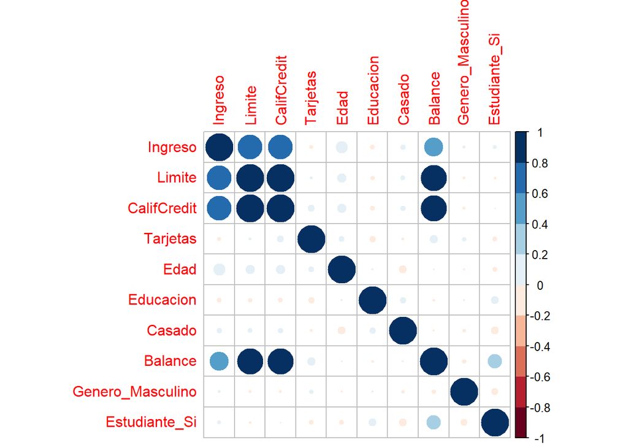

```r
corrplot(matriz.correlacion, col = COL2("RdBu", 10))
```

Interpretaciones:

Balance tiene correlación fuertemente positiva con limite y calificación crediticia lo que significa que los que a mayor calificación y mayor limite de crédito el promedio de deuda aumenta.

También el ingreso tiene correlación positiva con la calificación crediticia y el limite, si el ingreso crece la calificación y límite también y viceversa.

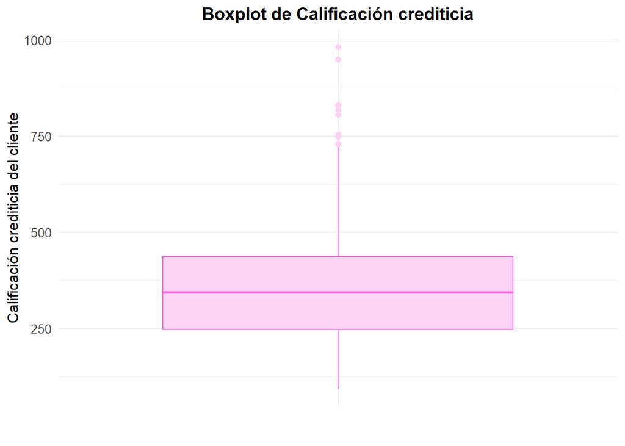

```r
ggplot(datos.credito2, aes(x = "", y = CalifCredit)) +
  geom_boxplot(fill = "#fdd3f4", color = "#fa68d8", outlier.colour = "#fdd3f4", outlier.size = 2) +
  labs(title = "Boxplot de Calificación crediticia",
       x = "",
       y = "Calificación crediticia del cliente") +
  theme_minimal() +
  theme(plot.title = element_text(hjust = 0.5, size = 14, face = "bold"),
        axis.title.y = element_text(size = 12),
        axis.text.y = element_text(size = 10))
```

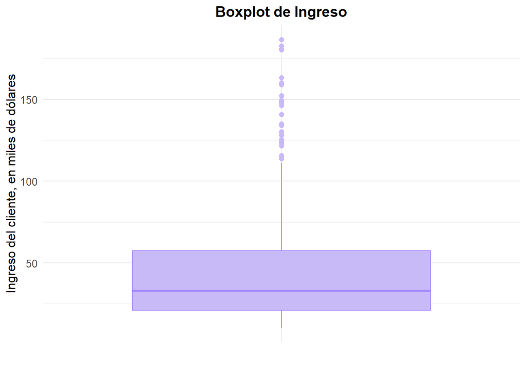

```r
ggplot(datos.credito2, aes(x = "", y = Ingreso)) +
  geom_boxplot(fill = "#c8b9f7", color = "#a58aff", outlier.colour = "#c8b9f7", outlier.size = 2) +
  labs(title = "Boxplot de Ingreso",
       x = "",
       y = "Ingreso del cliente, en miles de dólares") +
  theme_minimal() +
  theme(plot.title = element_text(hjust = 0.5, size = 14, face = "bold"),
        axis.title.y = element_text(size = 12),
        axis.text.y = element_text(size = 10))
```

Interpretación: Los valores atípicos son clientes con ingresos superiores a 100.000 dólares. En promedio la mayoría tiene un ingreso de 50.000.

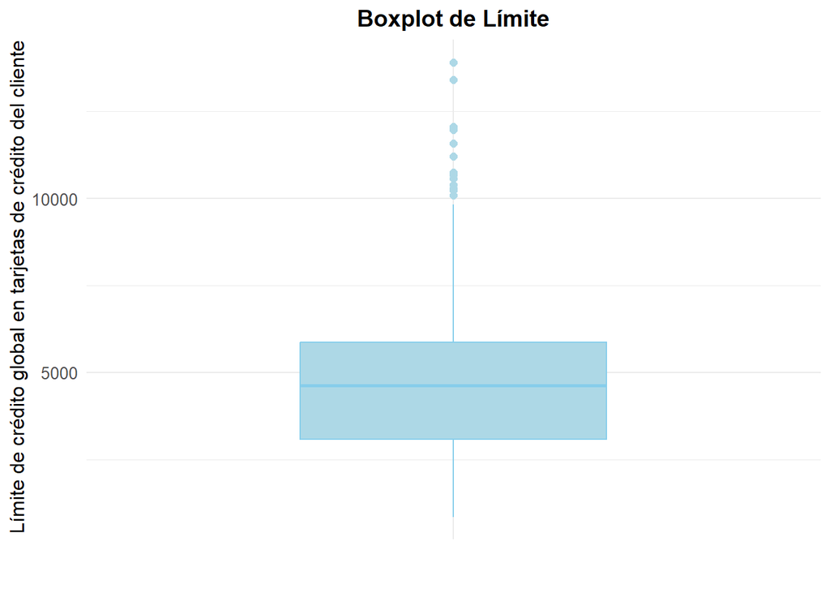

```r
# Boxplot para Límite
ggplot(datos.credito2, aes(x = "", y = Limite)) +
  geom_boxplot(fill = "lightblue", color = "skyblue", outlier.colour = "lightblue",position = "dodge", outlier.size = 2, width = 0.5) +
  labs(title = "Boxplot de Límite",
       x = "",
       y = " Límite de crédito global en tarjetas de crédito del cliente") +
  theme_minimal() +
  theme(plot.title = element_text(hjust = 0.5, size = 14, face = "bold"),
        axis.title.y = element_text(size = 12),
        axis.text.y = element_text(size = 10))
```

#### Ejercicio 3

Basado en las estadísticas básicas explique cuál variable numérica parece ser la mejor para predecir la deuda en tarjeta de crédito.

Basandonos en la matriz de correlación, se observa que la deuda en tarjeta de crédito tiene una correlación positiva fuerte con dos variables numéricas: Límite de crédito y calificación crediticia. La correlación entre el límite de crédito, la calificación crediticia y la deuda en tarjeta de crédito es alta, lo que sugiere que a medida que aumenta el límite de crédito y clientes con calificaciones crediticias, tienden a aumentar la deuda en la tarjeta. Ambas variables presentan una cantidad similar de valores atípicos, por lo que ambas podrían funcionar parecido para realizar la predicción.

#### Ejercicio 4

Genere un modelo de regresión lineal múltiple incluyendo las todas las variables predictoras. ¿Cuáles coeficientes obtiene para los β? Dé una interpretación de 3 de los coeficientes que se obtienen en el modelo. ¿Cuál variable parece tener més impacto sobre la variable a predecir y por qué?

```r
#Bondad de ajuste, se usa para predecir pero no para medir error
#usamos todos los datos
#efecto de cada variable predictora sobre la variable dependiente
modelo <- lm(Balance ~ ., data = datos.credito2)
modelo
```

```
##
## Call:
## lm(formula = Balance ~ ., data = datos.credito2)
##
## Coefficients:
##      (Intercept)           Ingreso            Limite       CalifCredit
##        -478.8104           -7.8020            0.1931            1.1023
##         Tarjetas              Edad         Educacion            Casado
##          17.9233           -0.6347           -1.1150           -7.0191
## Genero_Masculino     Estudiante_Si
##          10.4067          426.4692
```

```r
summary(modelo)
```

```
##
## Call:
## lm(formula = Balance ~ ., data = datos.credito2)
##
## Residuals:
##     Min      1Q  Median      3Q     Max
## -171.66  -75.32  -11.29   54.42  309.98
##
## Coefficients:
##                    Estimate Std. Error t value Pr(>|t|)
## (Intercept)      -478.81040   34.34301 -13.942  < 2e-16 ***
## Ingreso            -7.80200    0.23395 -33.349  < 2e-16 ***
## Limite              0.19308    0.03268   5.909 7.52e-09 ***
## CalifCredit         1.10227    0.48923   2.253   0.0248 *
## Tarjetas           17.92327    4.33228   4.137 4.31e-05 ***
## Edad               -0.63468    0.29325  -2.164   0.0310 *
## Educacion          -1.11503    1.59592  -0.699   0.4852
## Casado             -7.01910   10.27803  -0.683   0.4951
## Genero_Masculino   10.40665    9.90410   1.051   0.2940
## Estudiante_Si     426.46919   16.67770  25.571  < 2e-16 ***
## ---
## Signif. codes:  0 '***' 0.001 '**' 0.01 '*' 0.05 '.' 0.1 ' ' 1
##
## Residual standard error: 98.72 on 390 degrees of freedom
## Multiple R-squared:  0.9549, Adjusted R-squared:  0.9539
## F-statistic: 918.2 on 9 and 390 DF,  p-value: < 2.2e-16
```

1. Ingreso: Por cada unidad de aumento en el ingreso, el balance de la tarjeta de crédito disminuye en promedio $7.80. Esto sugiere que las personas con mayores ingresos tienden a tener un balance de tarjeta de crédito más bajo.
2. Limite: Por cada dólar de aumento en el límite de crédito, el balance de la tarjeta de crédito aumenta en promedio $0.19. Esto indica que las personas con límites de crédito más altos tienden a tener balances más altos.
3. Estudiante_Si: Este indica que los estudiantes tienen un balance de tarjeta de crédito promedio que es $426.47 mayor en comparación con los no estudiantes.

La variable Ingreso tiene el mayor impacto negativo en el balance. Un aumento en el ingreso se asocia con una disminución en el balance promedio, lo que podría indicar que los clientes con mayores ingresos tienden a manejar sus saldos de tarjeta de crédito más eficazmente.

#### Ejercicio 5

¿Qué error se obtiene sobre la tabla de testing para el modelo de regresión lineal? Interprete las medidas de error obtenidas.

```r
#Enfoque Training-Testing, medimos el error
#Lo hacemos con los datos de aprendizaje
modelo.lm <- lm(Balance ~., data = datos.aprendizaje)
modelo.lm
```

```
##
## Call:
## lm(formula = Balance ~ ., data = datos.aprendizaje)
##
## Coefficients:
##      (Intercept)           Ingreso            Limite       CalifCredit
##        -467.1758           -7.8235            0.2076            0.8903
##         Tarjetas              Edad         Educacion            Casado
##          18.0132           -0.9586            0.2867          -13.2660
## Genero_Masculino     Estudiante_Si
##          11.6359          421.4494
```

```r
#Funciones para medir el error
# Residual Sum of Square (RSS)
RSS <- function(Pred,Real) {
  ss <- sum((Real-Pred)^2)
  return(ss)
}

# NumPred es el número total de predictores por eso se resta 1 (que es realidad sumar 1)
RSE<-function(Pred,Real,NumPred) {
  N<-length(Real)-NumPred-1  # <- length(Real)-(NumPred+1)
  ss<-sqrt((1/N)*RSS(Pred,Real))
  return(ss)
}

MSE <- function(Pred,Real) {
  N<-length(Real)
  ss<-(1/N)*RSS(Pred,Real)
  return(ss)
}

error.relativo <- function(Pred,Real) {
  ss<-sum(abs(Real-Pred))/sum(abs(Real))
  return(ss)
}
# Funciones para desplegar precisión
indices.precision <- function(real, prediccion,cantidad.variables.predictoras) {
  return(list(error.cuadratico = MSE(prediccion,real),
              raiz.error.cuadratico = RSE(prediccion,real,cantidad.variables.predictoras),
              error.relativo = error.relativo(prediccion,real),
              correlacion = as.numeric(cor(prediccion,real))))
}


# Gráfico de dispersión entre el valor real de la variable a predecir y la predicción del modelo.
plot.real.prediccion <- function(real, prediccion, modelo = "") {
  g <- ggplot(data = data.frame(Real = real, Prediccion = as.numeric(prediccion)), mapping = aes(x = Real, y = Prediccion)) +
    geom_point(size = 1, col = "dodgerblue3") +
    labs(title = paste0("Real vs Predicción", ifelse(modelo == "", "", paste(", con", modelo))),
         x = "Real",
         y = "Predicción")
  return(g)
}
```

```r
#Hacer predicción con los datos de prueba
prediccion <- predict(modelo.lm, datos.prueba)

#Medimos precisión
pre.lm <- indices.precision(datos.prueba$Balance, prediccion, numero.predictoras)
pre.lm
```

```
## $error.cuadratico
## [1] 11273.08
##
## $raiz.error.cuadratico
## [1] 113.5056
##
## $error.relativo
## [1] 0.1752857
##
## $correlacion
## [1] 0.9729943
```

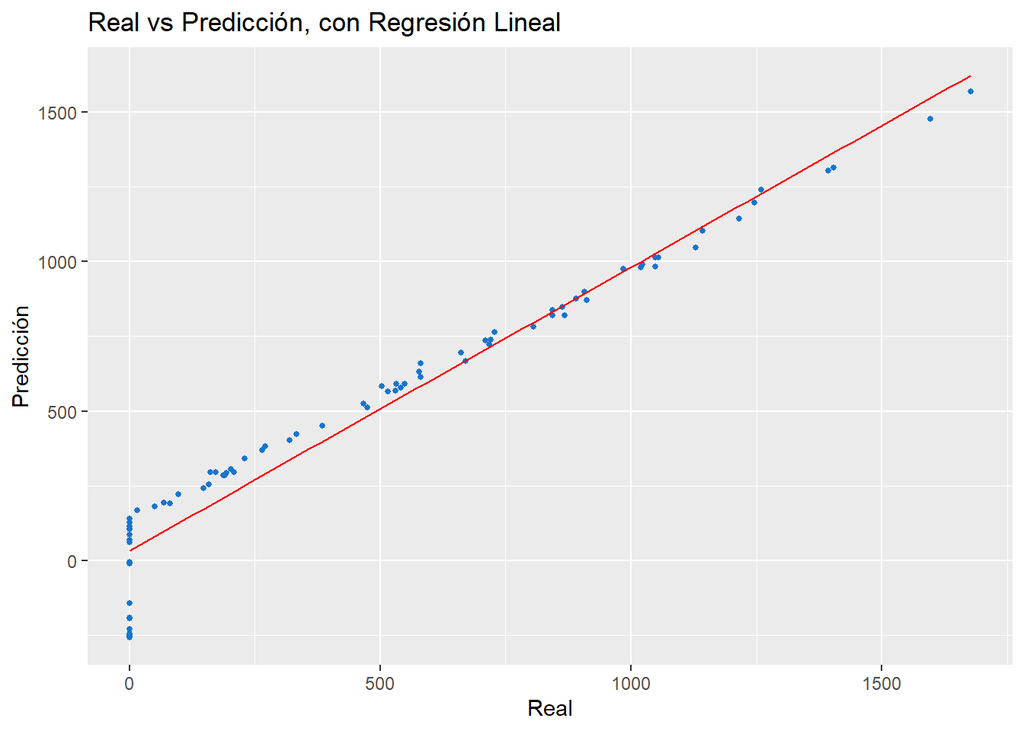

```r
#grafico
g <- plot.real.prediccion(datos.prueba$Balance, prediccion, modelo = "Regresión Lineal")
g + geom_smooth(method = lm, linewidth = 0.4, color = "red", se = FALSE)
```

#### Ejercicio 6

Si tuviera que eliminar alguna o algunas de las variables con la esperanza de que mejore la predicción ¿Cuál o cuáles de las variables eliminaría? ¿El nuevo modelo mejora la prediccón?

- Intentar con variables que no son significativas como la educación, el género y si es casado.

```r
#nuevo modelo
nuevo_modelo <- lm(Balance ~ Ingreso + Limite + CalifCredit + Tarjetas + Edad + Estudiante_Si, data = datos.aprendizaje)
summary(nuevo_modelo)
```

```
##
## Call:
## lm(formula = Balance ~ Ingreso + Limite + CalifCredit + Tarjetas +
##     Edad + Estudiante_Si, data = datos.aprendizaje)
##
## Residuals:
##     Min      1Q  Median      3Q     Max
## -157.00  -75.05  -10.23   58.33  307.61
##
## Coefficients:
##                 Estimate Std. Error t value Pr(>|t|)
## (Intercept)   -464.98873   27.49291 -16.913  < 2e-16 ***
## Ingreso         -7.82281    0.25082 -31.189  < 2e-16 ***
## Limite           0.21385    0.03553   6.018 4.93e-09 ***
## CalifCredit      0.79408    0.53380   1.488  0.13786
## Tarjetas        18.88635    4.67709   4.038 6.78e-05 ***
## Edad            -0.94106    0.32370  -2.907  0.00391 **
## Estudiante_Si  422.96721   18.98288  22.282  < 2e-16 ***
## ---
## Signif. codes:  0 '***' 0.001 '**' 0.01 '*' 0.05 '.' 0.1 ' ' 1
##
## Residual standard error: 97.09 on 313 degrees of freedom
## Multiple R-squared:  0.9562, Adjusted R-squared:  0.9554
## F-statistic:  1140 on 6 and 313 DF,  p-value: < 2.2e-16
```

```r
#comparar prediccion
nueva_prediccion <- predict(nuevo_modelo, datos.prueba)
nuevos_indices <- indices.precision(datos.prueba$Balance, nueva_prediccion, 6)  # 6 predictores ahora

#comparar indices de presición
print(pre.lm)  # Resultados del modelo original
```

```
## $error.cuadratico
## [1] 11273.08
##
## $raiz.error.cuadratico
## [1] 113.5056
##
## $error.relativo
## [1] 0.1752857
##
## $correlacion
## [1] 0.9729943
```

```r
print(nuevos_indices)  # Resultados del nuevo modelo
```

```
## $error.cuadratico
## [1] 11116.58
##
## $raiz.error.cuadratico
## [1] 110.3746
##
## $error.relativo
## [1] 0.1733041
##
## $correlacion
## [1] 0.9733594
```

- Error cuadrático: Bajó un poco, la mejora es ligera.
- Raíz del error cuadrático: Bajó. Predicciones ligeramente más precisas.
- Error relativo: Pequeña mejora en precisión porcentual.
- Correlación: iigual.

Interpretación simple: El nuevo modelo es ligeramente mejor. Predice con un poco más de precisión y es más simple. La mejora es pequeña, pero como el modelo usa menos variables y da resultados un poco mejores.

## Pregunta 2

Un cliente nos contrata para estudiar una posible oportunidad de negocio, y para ver si le es rentable quiere una predicción de las ventas potenciales de asientos de niños para autos en su tienda. Para ello hacemos uso de los datos AsientosNinno.csv los cual contienen detalles de ventas de asientos de niños para auto en una serie de tiendas similares a las del cliente, y además los datos incluyen variables que definen características de la tienda y su localidad. La tabla de datos está formada por 400 filas y 11 columnas.

#### Ejercicio 1

Cargue la tabla de datos en R. En caso de ser necesario, recodificar las variables de forma adecuada. Seleccione la variable a predecir, y para medir el error tome un 15 % de la tabla de datos.

```r
datos.asientos <- read.table("./DatosTarea2/AsientosNinno.csv", header = TRUE, sep = ";",dec='.', stringsAsFactors = TRUE)
str(datos.asientos)
```

```
## 'data.frame':    400 obs. of  12 variables:
##  $ X            : int  1 2 3 4 5 6 7 8 9 10 ...
##  $ Ventas       : num  9.5 11.22 10.06 7.4 4.15 ...
##  $ PrecioCompt  : int  138 111 113 117 141 124 115 136 132 132 ...
##  $ Ingreso      : int  73 48 35 100 64 113 105 81 110 113 ...
##  $ Publicidad   : int  11 16 10 4 3 13 0 15 0 0 ...
##  $ Poblacion    : int  276 260 269 466 340 501 45 425 108 131 ...
##  $ Precio       : int  120 83 80 97 128 72 108 120 124 124 ...
##  $ CalidadEstant: Factor w/ 3 levels "Bueno","Malo",..: 2 1 3 3 2 2 3 1 3 3 ...
##  $ Edad         : int  42 65 59 55 38 78 71 67 76 76 ...
##  $ Educacion    : int  17 10 12 14 13 16 15 10 10 17 ...
##  $ Urbano       : int  1 1 1 1 1 0 1 1 0 0 ...
##  $ USA          : int  1 1 1 1 0 1 0 1 0 1 ...
```

```r
dim(datos.asientos)
```

```
## [1] 400  12
```

```r
datos.sin.col <- datos.asientos[, -c(1)]
datos.asientos.ninos <- fastDummies::dummy_cols(datos.sin.col, select_columns = c("CalidadEstant"),
                                                remove_first_dummy = FALSE, remove_selected_columns = TRUE)
str(datos.asientos.ninos)
```

```
## 'data.frame':    400 obs. of  13 variables:
##  $ Ventas             : num  9.5 11.22 10.06 7.4 4.15 ...
##  $ PrecioCompt        : int  138 111 113 117 141 124 115 136 132 132 ...
##  $ Ingreso            : int  73 48 35 100 64 113 105 81 110 113 ...
##  $ Publicidad         : int  11 16 10 4 3 13 0 15 0 0 ...
##  $ Poblacion          : int  276 260 269 466 340 501 45 425 108 131 ...
##  $ Precio             : int  120 83 80 97 128 72 108 120 124 124 ...
##  $ Edad               : int  42 65 59 55 38 78 71 67 76 76 ...
##  $ Educacion          : int  17 10 12 14 13 16 15 10 10 17 ...
##  $ Urbano             : int  1 1 1 1 1 0 1 1 0 0 ...
##  $ USA                : int  1 1 1 1 0 1 0 1 0 1 ...
##  $ CalidadEstant_Bueno: int  0 1 0 0 0 0 0 1 0 0 ...
##  $ CalidadEstant_Malo : int  1 0 0 0 1 1 0 0 0 0 ...
##  $ CalidadEstant_Medio: int  0 0 1 1 0 0 1 0 1 1 ...
```

```r
#Dividimos los datos en conjunto de entrenamiento y prueba
#Variable que vamos a predecir
ventas <- datos.asientos.ninos$Ventas

numero.predictoras.asientos <- dim(datos.asientos.ninos)[2] - 1

#obtenemos el nummero de filas
numero.filas.asientos <- nrow(datos.asientos.ninos)

#Creamos muestra aleatoria de filas que representan el 15% del total de filas
muestra.asientos <- sample(1:numero.filas.asientos, numero.filas.asientos*0.15)

#datos para entrenar 75%
datos.aprendizaje.asientos <- datos.asientos.ninos[-muestra,]

datos.prueba.asientos <- datos.asientos.ninos[muestra,]

dim(datos.prueba.asientos)
```

```
## [1] 80 13
```

```r
dim(datos.aprendizaje.asientos)
```

```
## [1] 320  13
```

#### Ejercicio 2

Realice un Análisis Exploratorio de los datos con todos los datos que incluya al menos:

- summary(…).
- La matriz de correlaciones y alguno de sus gráficos. Interprete al menos dos correlaciones.
- Encuentre al menos 3 datos atípicos, si es que existen en esta tabla de datos.

```r
library(GGally)
library(corrplot)
summary(datos.asientos.ninos)
```

```
##      Ventas        PrecioCompt     Ingreso         Publicidad
##  Min.   : 0.000   Min.   : 77   Min.   : 21.00   Min.   : 0.000
##  1st Qu.: 5.390   1st Qu.:115   1st Qu.: 42.75   1st Qu.: 0.000
##  Median : 7.490   Median :125   Median : 69.00   Median : 5.000
##  Mean   : 7.496   Mean   :125   Mean   : 68.66   Mean   : 6.635
##  3rd Qu.: 9.320   3rd Qu.:135   3rd Qu.: 91.00   3rd Qu.:12.000
##  Max.   :16.270   Max.   :175   Max.   :120.00   Max.   :29.000
##    Poblacion         Precio           Edad         Educacion        Urbano
##  Min.   : 10.0   Min.   : 24.0   Min.   :25.00   Min.   :10.0   Min.   :0.000
##  1st Qu.:139.0   1st Qu.:100.0   1st Qu.:39.75   1st Qu.:12.0   1st Qu.:0.000
##  Median :272.0   Median :117.0   Median :54.50   Median :14.0   Median :1.000
##  Mean   :264.8   Mean   :115.8   Mean   :53.32   Mean   :13.9   Mean   :0.705
##  3rd Qu.:398.5   3rd Qu.:131.0   3rd Qu.:66.00   3rd Qu.:16.0   3rd Qu.:1.000
##  Max.   :509.0   Max.   :191.0   Max.   :80.00   Max.   :18.0   Max.   :1.000
##       USA        CalidadEstant_Bueno CalidadEstant_Malo CalidadEstant_Medio
##  Min.   :0.000   Min.   :0.0000      Min.   :0.00       Min.   :0.0000
##  1st Qu.:0.000   1st Qu.:0.0000      1st Qu.:0.00       1st Qu.:0.0000
##  Median :1.000   Median :0.0000      Median :0.00       Median :1.0000
##  Mean   :0.645   Mean   :0.2125      Mean   :0.24       Mean   :0.5475
##  3rd Qu.:1.000   3rd Qu.:0.0000      3rd Qu.:0.00       3rd Qu.:1.0000
##  Max.   :1.000   Max.   :1.0000      Max.   :1.00       Max.   :1.0000
```

```r
matriz.correlacion.asientos <- cor(datos.asientos.ninos)
matriz.correlacion.asientos
```

```
##                          Ventas  PrecioCompt      Ingreso   Publicidad
## Ventas               1.00000000  0.064078730  0.151950979  0.269506781
## PrecioCompt          0.06407873  1.000000000 -0.080653423 -0.024198788
## Ingreso              0.15195098 -0.080653423  1.000000000  0.058994706
## Publicidad           0.26950678 -0.024198788  0.058994706  1.000000000
## Poblacion            0.05047098 -0.094706516 -0.007876994  0.265652145
## Precio              -0.44495073  0.584847767 -0.056698202  0.044536874
## Edad                -0.23181544 -0.100238817 -0.004670094 -0.004557497
## Educacion           -0.05195524  0.025197050 -0.056855422 -0.033594307
## Urbano              -0.01541944  0.066594401  0.037967176  0.042034534
## USA                  0.17709327  0.016868865  0.089601328  0.684460204
## CalidadEstant_Bueno  0.50051013  0.026386060 -0.012656750  0.056148889
## CalidadEstant_Malo  -0.39316690 -0.035392577  0.072017271 -0.035216906
## CalidadEstant_Medio -0.07399884  0.008682569 -0.051391992 -0.015929357
##                        Poblacion       Precio         Edad    Educacion
## Ventas               0.050470984 -0.444950728 -0.231815440 -0.051955242
## PrecioCompt         -0.094706516  0.584847767 -0.100238817  0.025197050
## Ingreso             -0.007876994 -0.056698202 -0.004670094 -0.056855422
## Publicidad           0.265652145  0.044536874 -0.004557497 -0.033594307
## Poblacion            1.000000000 -0.012143620 -0.042663355 -0.106378231
## Precio              -0.012143620  1.000000000 -0.102176839  0.011746599
## Edad                -0.042663355 -0.102176839  1.000000000  0.006488032
## Educacion           -0.106378231  0.011746599  0.006488032  1.000000000
## Urbano              -0.052024635  0.047016126  0.028478596 -0.033093770
## USA                  0.060563613  0.057861264  0.008652076 -0.078250434
## CalidadEstant_Bueno  0.007789034  0.045853565 -0.022818266 -0.029187708
## CalidadEstant_Malo   0.039902479 -0.036220489 -0.044123056  0.012524787
## CalidadEstant_Medio -0.040639778 -0.006606811  0.056613315  0.013241661
##                          Urbano           USA CalidadEstant_Bueno
## Ventas              -0.01541944  0.1770932680         0.500510126
## PrecioCompt          0.06659440  0.0168688654         0.026386060
## Ingreso              0.03796718  0.0896013283        -0.012656750
## Publicidad           0.04203453  0.6844602044         0.056148889
## Poblacion           -0.05202463  0.0605636126         0.007789034
## Precio               0.04701613  0.0578612645         0.045853565
## Edad                 0.02847860  0.0086520757        -0.022818266
## Educacion           -0.03309377 -0.0782504342        -0.029187708
## Urbano               1.00000000  0.0470849626        -0.039197247
## USA                  0.04708496  1.0000000000         0.078863889
## CalidadEstant_Bueno -0.03919725  0.0788638888         1.000000000
## CalidadEstant_Malo   0.08112208  0.0009786413        -0.291912714
## CalidadEstant_Medio -0.03739150 -0.0656556243        -0.571395684
##                     CalidadEstant_Malo CalidadEstant_Medio
## Ventas                   -0.3931668974        -0.073998844
## PrecioCompt              -0.0353925766         0.008682569
## Ingreso                   0.0720172712        -0.051391992
## Publicidad               -0.0352169055        -0.015929357
## Poblacion                 0.0399024785        -0.040639778
## Precio                   -0.0362204894        -0.006606811
## Edad                     -0.0441230558         0.056613315
## Educacion                 0.0125247865         0.013241661
## Urbano                    0.0811220848        -0.037391498
## USA                       0.0009786413        -0.065655624
## CalidadEstant_Bueno      -0.2919127140        -0.571395684
## CalidadEstant_Malo        1.0000000000        -0.618132523
## CalidadEstant_Medio      -0.6181325232         1.000000000
```

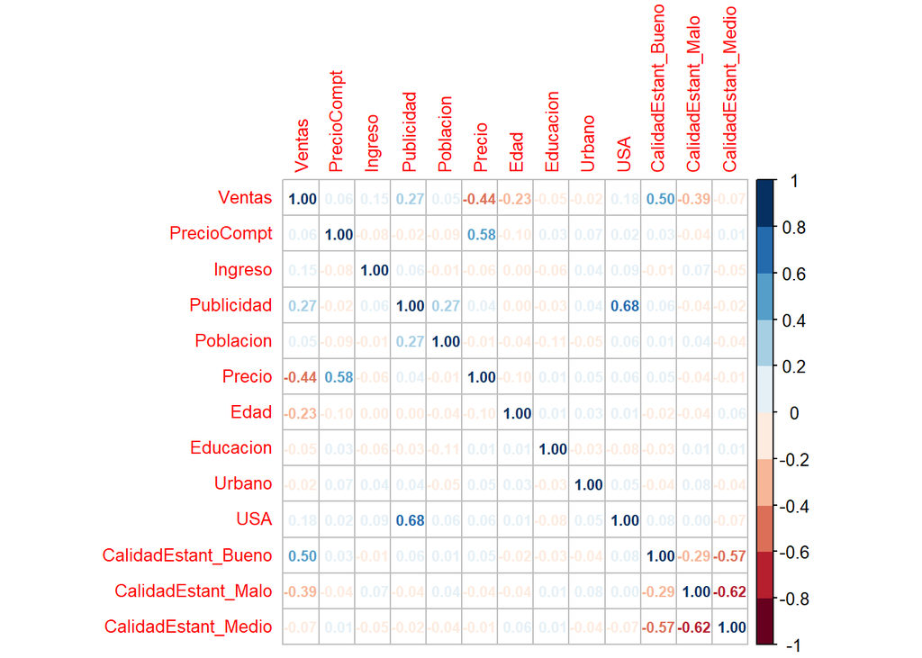

```r
corrplot(matriz.correlacion.asientos, method = "number", col = COL2("RdBu", 10), tl.cex = 0.8, number.cex = 0.7)
```

Interpretaciones:

- Ventas y calidad de estante(0.50) tienen una correlación positiva, mostrando que cuando los asientos están bien ubicados en estantes de buena calidad, las ventas tienden a ser mayores.
- Ventas y precio cobrado(-0.44) tienen una correlación negativa. Sugiere que a medida que aumenta el precio, las ventas tienden a disminuir y viceversa.
- Ventas y publicidad(0.27) tienen una correlación positiva, lo que indica que gastar más en publicidad puede ayudar a aumentar las ventas.

```r
find_outliers_boxplot <- function(x) {
  return(boxplot.stats(x)$out)
}

# Encontrar outliers usando Boxplot Method
outliers_boxplot <- lapply(datos.aprendizaje.asientos, find_outliers_boxplot)

outliers_boxplot
```

```
## $Ventas
## [1] 16.27
##
## $PrecioCompt
## [1]  85 175
##
## $Ingreso
## integer(0)
##
## $Publicidad
## integer(0)
##
## $Poblacion
## integer(0)
##
## $Precio
## [1]  49 191  55 185  53
##
## $Edad
## integer(0)
##
## $Educacion
## integer(0)
##
## $Urbano
## integer(0)
##
## $USA
## integer(0)
##
## $CalidadEstant_Bueno
##  [1] 1 1 1 1 1 1 1 1 1 1 1 1 1 1 1 1 1 1 1 1 1 1 1 1 1 1 1 1 1 1 1 1 1 1 1 1 1 1
## [39] 1 1 1 1 1 1 1 1 1 1 1 1 1 1 1 1 1 1 1 1 1 1 1 1 1 1 1 1 1 1 1 1 1 1 1 1
##
## $CalidadEstant_Malo
##  [1] 1 1 1 1 1 1 1 1 1 1 1 1 1 1 1 1 1 1 1 1 1 1 1 1 1 1 1 1 1 1 1 1 1 1 1 1 1 1
## [39] 1 1 1 1 1 1 1 1 1 1 1 1 1 1 1 1 1 1 1 1 1 1 1 1 1 1 1 1 1 1 1 1 1 1 1 1 1
##
## $CalidadEstant_Medio
## integer(0)
```

Ventas, PrecioCompt y Precio tienen datos atípicos.

#### Ejercicio 3

Aplique el modelo de regresión lineal múltiple incluyendo todas las variables predictoras.

```r
#1 crear modelo
modelo.asientos <- lm(Ventas ~ ., data = datos.asientos.ninos)
summary(modelo.asientos)
```

```
##
## Call:
## lm(formula = Ventas ~ ., data = datos.asientos.ninos)
##
## Residuals:
##     Min      1Q  Median      3Q     Max
## -2.8692 -0.6908  0.0211  0.6636  3.4115
##
## Coefficients: (1 not defined because of singularities)
##                       Estimate Std. Error t value Pr(>|t|)
## (Intercept)          7.6173379  0.5974148  12.751  < 2e-16 ***
## PrecioCompt          0.0928153  0.0041477  22.378  < 2e-16 ***
## Ingreso              0.0158028  0.0018451   8.565 2.58e-16 ***
## Publicidad           0.1230951  0.0111237  11.066  < 2e-16 ***
## Poblacion            0.0002079  0.0003705   0.561    0.575
## Precio              -0.0953579  0.0026711 -35.700  < 2e-16 ***
## Edad                -0.0460452  0.0031817 -14.472  < 2e-16 ***
## Educacion           -0.0211018  0.0197205  -1.070    0.285
## Urbano               0.1228864  0.1129761   1.088    0.277
## USA                 -0.1840928  0.1498423  -1.229    0.220
## CalidadEstant_Bueno  2.8934679  0.1308928  22.106  < 2e-16 ***
## CalidadEstant_Malo  -1.9567148  0.1261056 -15.516  < 2e-16 ***
## CalidadEstant_Medio         NA         NA      NA       NA
## ---
## Signif. codes:  0 '***' 0.001 '**' 0.01 '*' 0.05 '.' 0.1 ' ' 1
##
## Residual standard error: 1.019 on 388 degrees of freedom
## Multiple R-squared:  0.8734, Adjusted R-squared:  0.8698
## F-statistic: 243.4 on 11 and 388 DF,  p-value: < 2.2e-16
```

Precio (-0.095), un aumento en el precio reduce las ventas. Publicidad (0.123), un aumento en el gasto publicitario incrementa las ventas. CalidadEstant_Bueno (2.893), mejorar la ubicación de los asientos en los estantes aumenta las ventas. Esta es la variable que tiene mayor impacto en las ventas.

#### Ejercicio 4

¿Qué error se obtiene sobre la tabla de training para el modelo generado anteriormente?

```r
#datos aprendizaje
modelo.asientos.lm <- lm(Ventas ~., data = datos.aprendizaje.asientos)
summary(modelo.asientos.lm)
```

```
##
## Call:
## lm(formula = Ventas ~ ., data = datos.aprendizaje.asientos)
##
## Residuals:
##     Min      1Q  Median      3Q     Max
## -2.7567 -0.7353  0.0444  0.6411  3.3091
##
## Coefficients: (1 not defined because of singularities)
##                       Estimate Std. Error t value Pr(>|t|)
## (Intercept)          7.4901661  0.6863561  10.913  < 2e-16 ***
## PrecioCompt          0.0905239  0.0046533  19.454  < 2e-16 ***
## Ingreso              0.0161432  0.0020100   8.032 2.06e-14 ***
## Publicidad           0.1236397  0.0120968  10.221  < 2e-16 ***
## Poblacion            0.0004202  0.0004225   0.994    0.321
## Precio              -0.0945893  0.0030413 -31.101  < 2e-16 ***
## Edad                -0.0473563  0.0035771 -13.239  < 2e-16 ***
## Educacion            0.0012302  0.0218806   0.056    0.955
## Urbano               0.1361101  0.1253871   1.086    0.279
## USA                 -0.1626104  0.1680929  -0.967    0.334
## CalidadEstant_Bueno  2.8231850  0.1427919  19.771  < 2e-16 ***
## CalidadEstant_Malo  -2.0052329  0.1424214 -14.080  < 2e-16 ***
## CalidadEstant_Medio         NA         NA      NA       NA
## ---
## Signif. codes:  0 '***' 0.001 '**' 0.01 '*' 0.05 '.' 0.1 ' ' 1
##
## Residual standard error: 1.016 on 308 degrees of freedom
## Multiple R-squared:  0.8745, Adjusted R-squared:   0.87
## F-statistic: 195.1 on 11 and 308 DF,  p-value: < 2.2e-16
```

```r
#predicción con datos de prueba
prediccion.asientos <- predict(modelo.asientos.lm, datos.prueba.asientos)

#medir precisión
pre.lm.asientos <- indices.precision(datos.prueba.asientos$Ventas, prediccion.asientos, numero.predictoras.asientos)
pre.lm.asientos
```

```
## $error.cuadratico
## [1] 1.090918
##
## $raiz.error.cuadratico
## [1] 1.14131
##
## $error.relativo
## [1] 0.113363
##
## $correlacion
## [1] 0.9302471
```

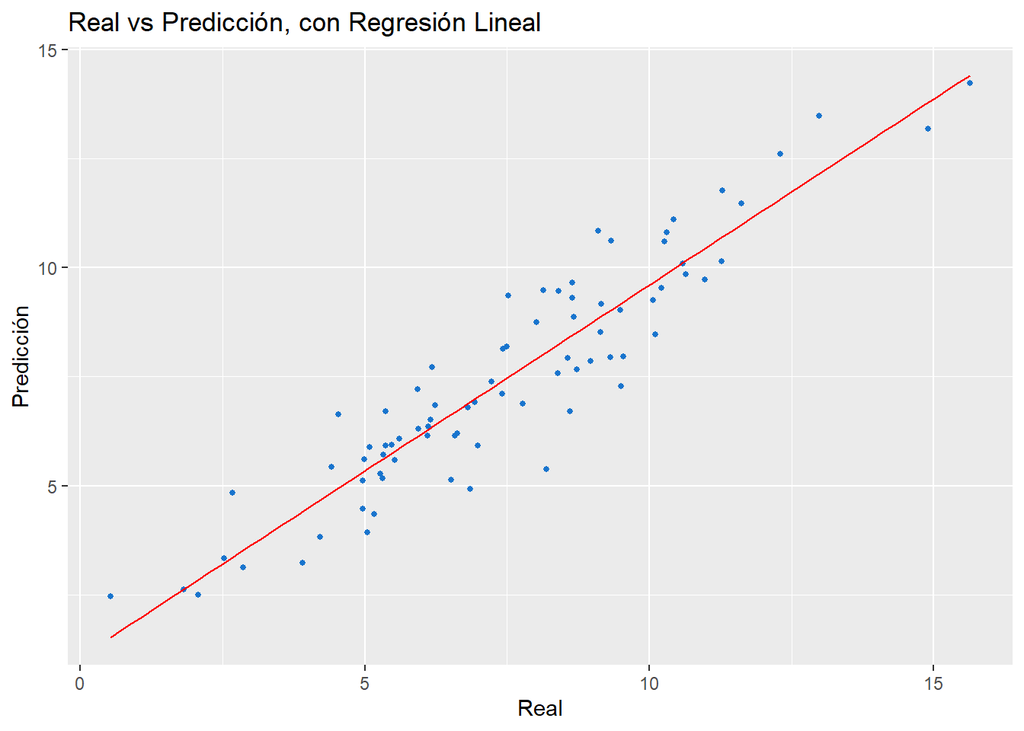

```r
#grafico
g <- plot.real.prediccion(datos.prueba.asientos$Ventas, prediccion.asientos, modelo = "Regresión Lineal")
g + geom_smooth(method = lm, linewidth = 0.4, color = "red", se = FALSE)
```

## Pregunta 3

La Tabla de Datos uscrime.csv contiene el cálculo de índice de crímenes violentos por habitante en Estados Unidos, como son el asesinato, la violación, el robo y asalto. Las variables incluidas son, entre otras, el porcentaje de la población considerada urbana, la renta media de la familia, la participación de las fuerzas del orden, el número de policías per cápita, el porcentaje de los oficiales asignados a las unidades de la droga. La variable a predecir es ViolentCrimesPerPop (Per Capita Violent Crimes in US). Usando un 67 % de esta tabla para Tabla de Aprendizaje y el restante 33 % para Tabla de Testing.

#### Ejercicio 1

Realice un Análisis Exploratorio de los datos con todos los datos.

```r
library(corrplot)

datos.crimen <- read.table("./DatosTarea2/uscrime.csv", header = TRUE, sep = ",",dec='.', stringsAsFactors = TRUE)
#str(datos3)
dim(datos.crimen)
```

```
## [1] 1994  103
```

```r
str(datos.crimen)
```

```
## 'data.frame':    1994 obs. of  103 variables:
##  $ state                : int  8 53 24 34 42 6 44 6 21 29 ...
##  $ fold                 : int  1 1 1 1 1 1 1 1 1 1 ...
##  $ population           : num  0.19 0 0 0.04 0.01 0.02 0.01 0.01 0.03 0.01 ...
##  $ householdsize        : num  0.33 0.16 0.42 0.77 0.55 0.28 0.39 0.74 0.34 0.4 ...
##  $ racepctblack         : num  0.02 0.12 0.49 1 0.02 0.06 0 0.03 0.2 0.06 ...
##  $ racePctWhite         : num  0.9 0.74 0.56 0.08 0.95 0.54 0.98 0.46 0.84 0.87 ...
##  $ racePctAsian         : num  0.12 0.45 0.17 0.12 0.09 1 0.06 0.2 0.02 0.3 ...
##  $ racePctHisp          : num  0.17 0.07 0.04 0.1 0.05 0.25 0.02 1 0 0.03 ...
##  $ agePct12t21          : num  0.34 0.26 0.39 0.51 0.38 0.31 0.3 0.52 0.38 0.9 ...
##  $ agePct12t29          : num  0.47 0.59 0.47 0.5 0.38 0.48 0.37 0.55 0.45 0.82 ...
##  $ agePct16t24          : num  0.29 0.35 0.28 0.34 0.23 0.27 0.23 0.36 0.28 0.8 ...
##  $ agePct65up           : num  0.32 0.27 0.32 0.21 0.36 0.37 0.6 0.35 0.48 0.39 ...
##  $ numbUrban            : num  0.2 0.02 0 0.06 0.02 0.04 0.02 0 0.04 0.02 ...
##  $ pctUrban             : num  1 1 0 1 0.9 1 0.81 0 1 1 ...
```

[output cut: 86 more lines]

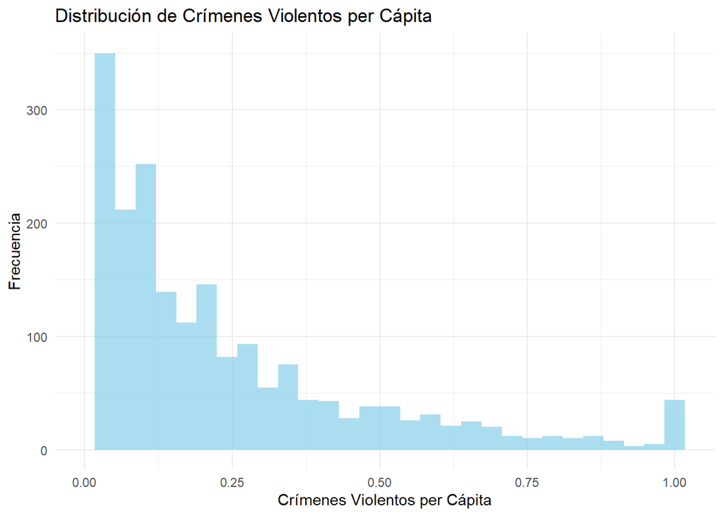

```r
# Histograma de la variable objetivo
ggplot(datos.crimen, aes(x = ViolentCrimesPerPop)) +
  geom_histogram(bins = 30, fill = "skyblue", alpha = 0.7) +
  theme_minimal() +
  labs(title = "Distribución de Crímenes Violentos per Cápita",
       x = "Crímenes Violentos per Cápita",
       y = "Frecuencia") +
  scale_x_continuous(limits = c(0, NA))
```

```r
#Primeras 5 correlaciones positivas y las negativas
cor.matrix <- cor(datos.crimen)


correlaciones <- cor.matrix[,"ViolentCrimesPerPop"]
abs_correlations <- abs(correlaciones)

positive_correlations <- correlaciones[correlaciones > 0]
negative_correlations <- correlaciones[correlaciones < 0]


top.cor.positivas <- sort(positive_correlations, decreasing = TRUE)[2:6]
top.cor.negativas <- sort(negative_correlations, decreasing = FALSE)[1:5]

print(top.cor.positivas)
```

```
##     PctIlleg racepctblack  pctWPubAsst FemalePctDiv  TotalPctDiv
##    0.7379565    0.6312636    0.5746653    0.5560319    0.5527774
```

```r
print(top.cor.negativas)
```

```
##      PctKids2Par       PctFam2Par     racePctWhite PctYoungKids2Par
##       -0.7384238       -0.7066675       -0.6847696       -0.6660589
##      PctTeen2Par
##       -0.6615816
```

```r
#Valores atípicos
z_scores <- as.data.frame(scale(datos.crimen))
outliers <- which(abs(z_scores$ViolentCrimesPerPop) > 3)
print(paste("Número de valores atípicos en ViolentCrimesPerPop:", length(outliers)))
```

```
## [1] "Número de valores atípicos en ViolentCrimesPerPop: 50"
```

#### Ejercicio 2

Construya un modelo predictivo para la variable ViolentCrimesPerPop usando una Regresión Lineal Múltiple con la función lm(…) en la Tabla de Aprendizaje y calcule Error Estándar de los Residuos para este modelo, además calcule el Error Cuadrático Medio y el Error Relativo para la Tabla de Testing.

```r
#Dividimos los datos en conjunto de entrenamiento y prueba
#Variable que vamos a predecir
violentCrimesPerPop <- datos.crimen$ViolentCrimesPerPop

numero.predictoras.crimen <- dim(datos.crimen)[2] - 1

#obtenemos el nummero de filas
numero.filas.crimen <- nrow(datos.crimen)

#Creamos muestra aleatoria de filas que representan el 33% del total de filas
muestra.crimen <- sample(1:numero.filas.crimen, numero.filas.crimen*0.33)

#datos para entrenar 67%
datos.aprendizaje.crimen <- datos.crimen[-muestra,]

datos.prueba.crimen <- datos.crimen[muestra,]

#datos aprendizaje
modelo.crimen.lm <- lm(ViolentCrimesPerPop~., data = datos.aprendizaje.crimen)

#prediccion con datos de prueba
prediccion.crimen <- predict(modelo.crimen.lm, datos.prueba.crimen)

#medir precision
pre.lm.crimen <- indices.precision(datos.prueba.crimen$ViolentCrimesPerPop, prediccion.crimen, numero.predictoras.crimen)
pre.lm.crimen
```

```
## $error.cuadratico
## [1] 0.02861087
##
## $raiz.error.cuadratico
## [1] NaN
##
## $error.relativo
## [1] 0.4352875
##
## $correlacion
## [1] 0.7467636
```

```r
mse <- mean((datos.prueba.crimen$ViolentCrimesPerPop - prediccion.crimen)^2)

rmse <- sqrt(mse)
print("raiz error cuadratico")
```

```
## [1] "raiz error cuadratico"
```

```r
print(rmse)
```

```
## [1] 0.1691475
```

## Pregunta Optativa

#### Ejercicio 1

Programe en R una función lm2(…) que recibe como parámetro una tabla de aprendizaje y retorna un modelo de Regresión Lineal.

```r
lm2 <- function(data) {
  y <- data$ViolentCrimesPerPop
  X <- as.matrix(cbind(1, data[, -which(names(data) == "ViolentCrimesPerPop")]))
  beta <- solve(t(X) %*% X) %*% t(X) %*% y
  return(list(coefficients = beta))
}
```

#### Ejercicio 2

Programe en R una función predict2(…) que recibe como parámetro el modelo construido en la pregunta anterior, una tabla de testing de modo tal que retorna la predicción para esta tabla de testing.

```r
predict2 <- function(model, newdata) {
  X <- as.matrix(cbind(1, newdata[, -which(names(newdata) == "ViolentCrimesPerPop")]))
  return(X %*% model$coefficients)
}
```

#### Ejercicio 3

Usando la tabla de datos uscrime.csv compare los resultados de las funciones lm(…), lm2(…), predict(…) y predict2(…).

```r
# Modelos
modelo_lm <- lm(ViolentCrimesPerPop ~ ., data = datos.aprendizaje.crimen)
modelo_lm2 <- lm2(datos.aprendizaje.crimen)

# Predicciones
pred_lm <- predict(modelo_lm, datos.prueba.crimen)
pred_lm2 <- predict2(modelo_lm2, datos.prueba.crimen)

# Comparación
print(head(pred_lm))
```

```
##        28       284        95       250       317        39
## 0.1186794 0.2362034 0.1551276 0.1032972 0.6375785 0.2475192
```

```r
print(head(pred_lm2))
```

```
##          [,1]
## 28  0.1186794
## 284 0.2362034
## 95  0.1551276
## 250 0.1032972
## 317 0.6375785
## 39  0.2475192
```

```r
print(sum(abs(pred_lm - pred_lm2)))  # Diferencia total
```

```
## [1] 4.278887e-11
```

#### Ejercicio 4

Usando la tabla de datos uscrime.csv y la función de R denominada system.time(…) compare los tiempos de ejecuci´on de las funciones lm(…), lm2(…), predict(…) y predict2(…).

```r
# Tiempo para lm y predict
tiempo_lm <- system.time({
  modelo_lm <- lm(ViolentCrimesPerPop ~ ., data = datos.aprendizaje.crimen)
  pred_lm <- predict(modelo_lm, datos.prueba.crimen)
})

# Tiempo para lm2 y predict2
tiempo_lm2 <- system.time({
  modelo_lm2 <- lm2(datos.aprendizaje.crimen)
  pred_lm2 <- predict2(modelo_lm2, datos.prueba.crimen)
})

print("Tiempo para lm y predict:")
```

```
## [1] "Tiempo para lm y predict:"
```

```r
print(tiempo_lm)
```

```
##    user  system elapsed
##    0.00    0.00    0.05
```

```r
print("Tiempo para lm2 y predict2:")
```

```
## [1] "Tiempo para lm2 y predict2:"
```

```r
print(tiempo_lm2)
```

```
##    user  system elapsed
##    0.00    0.00    0.03
```